# Data visualisation tutorial

By Rike Bolam

Last updated 15/07/2020

## Learning outcomes

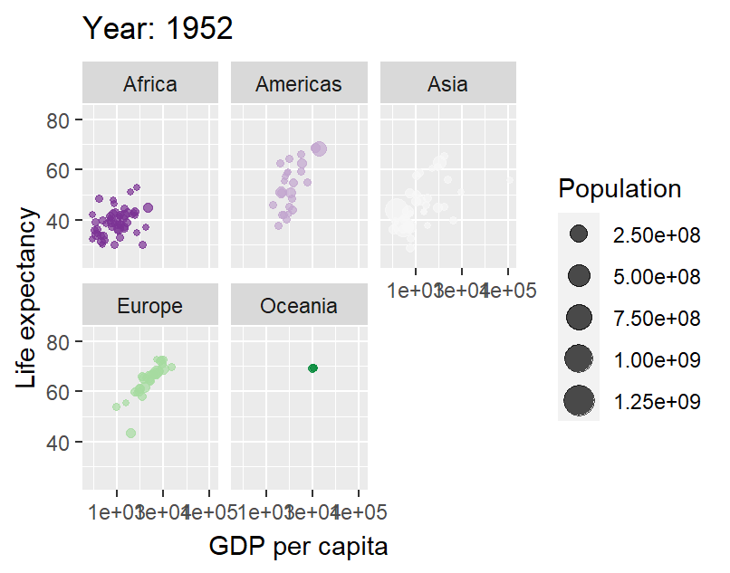

## Getting started

Please note: the code you need to type is in the grey boxes. Sometimes comments are added following a #, to further explain some of the code.

To start using ggplot2, first open RStudio, then install and load the package using `install.packages("ggplot2)`, then `library(ggplot2)`.

There is a lot of information about ggplot2 online, so if you get stuck you can try to google what you are trying to do. There is also a useful data visualisation cheat sheet - once you have used ggplot2 a bit, it will become more and more useful: https://www.rstudio.com/resources/cheatsheets/

## A very basic plot in ggplot2

We will use data that are in-built for this session, the gapminder dataset.

```r
str(gapminder)
```

```
## tibble [1,704 x 6] (S3: tbl_df/tbl/data.frame)
##  $ country  : Factor w/ 142 levels "Afghanistan",..: 1 1 1 1 1 1 1 1 1 1 ...
##  $ continent: Factor w/ 5 levels "Africa","Americas",..: 3 3 3 3 3 3 3 3 3 3 ...
##  $ year     : int [1:1704] 1952 1957 1962 1967 1972 1977 1982 1987 1992 1997 ...
##  $ lifeExp  : num [1:1704] 28.8 30.3 32 34 36.1 ...
##  $ pop      : int [1:1704] 8425333 9240934 10267083 11537966 13079460 14880372 12881816 13867957 16317921 22227415 ...
##  $ gdpPercap: num [1:1704] 779 821 853 836 740 ...
```

```r
# Have a look at the gapminder dataset, so you know which variables there are and what types of variables they are
```

We will start with some short code that will produce a plot in ggplot2. The basic pattern of the ggplot2 function first names the dataset, then the x and y variables. With `geom_`, you add the type of plot you want:

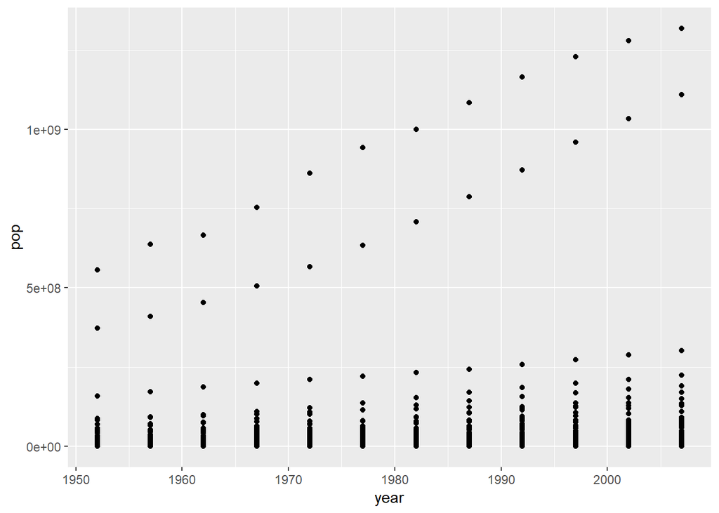

```r
ggplot(data = gapminder, aes(x = year, y = pop)) +
  geom_point()
```

```r
# this will now produce a basic scatterplot
```

The plot will be empty if you don’t specify the type of plot you want:

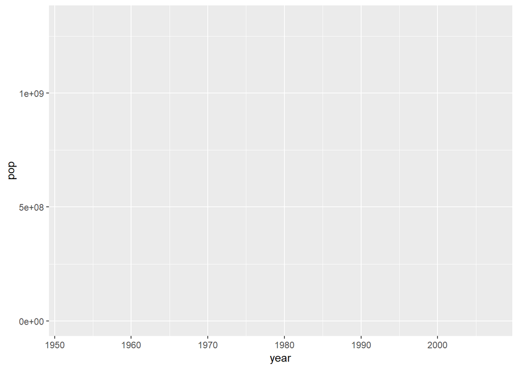

```r
ggplot(data = gapminder, aes(x = year, pop))
```

## Customising a plot

### Axis labels

We can now start to customise the plot, so it looks exactly how we want it to look. We can change the axis labels by adding `xlab` or `ylab`:

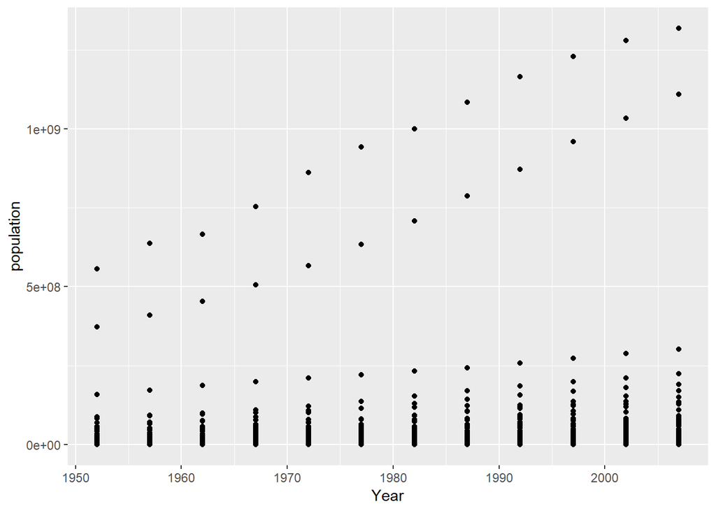

```r
ggplot(data = gapminder, aes(x = year, y = pop)) +
  geom_point() +
  xlab("Year") +
  ylab("population")
```

### Size and transparency

If you have a lot of data points, it can be difficult to see all of the points as they might overlap. You can change the size or transparency of the points so they are easier to see, or move them about:

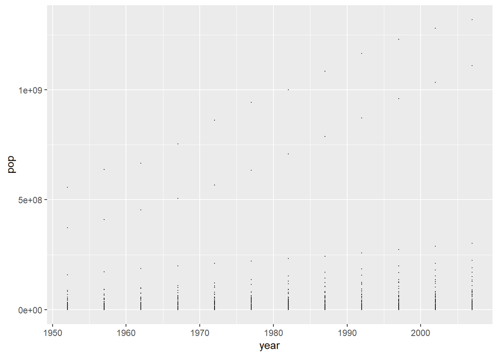

```r
ggplot(data = gapminder, aes(x = year, y = pop)) +
  geom_point(size = 0.1)
```

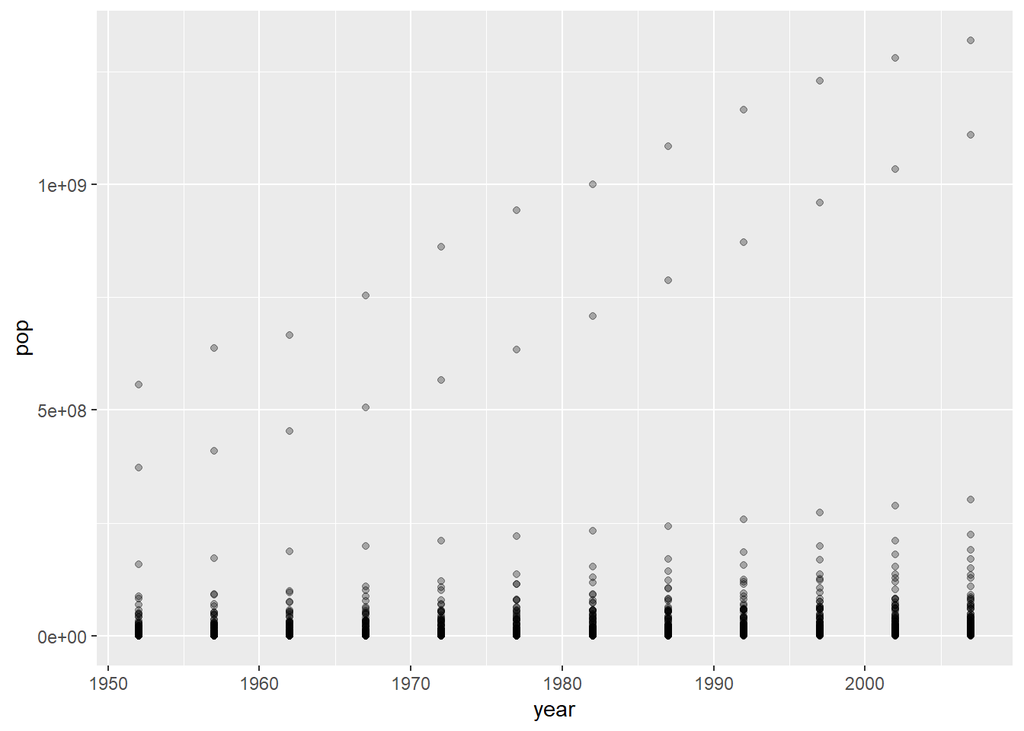

```r
# changing the size to 3 will make the dots bigger


ggplot(data = gapminder, aes(x = year, y = pop)) +
  geom_point(alpha = 0.3)
```

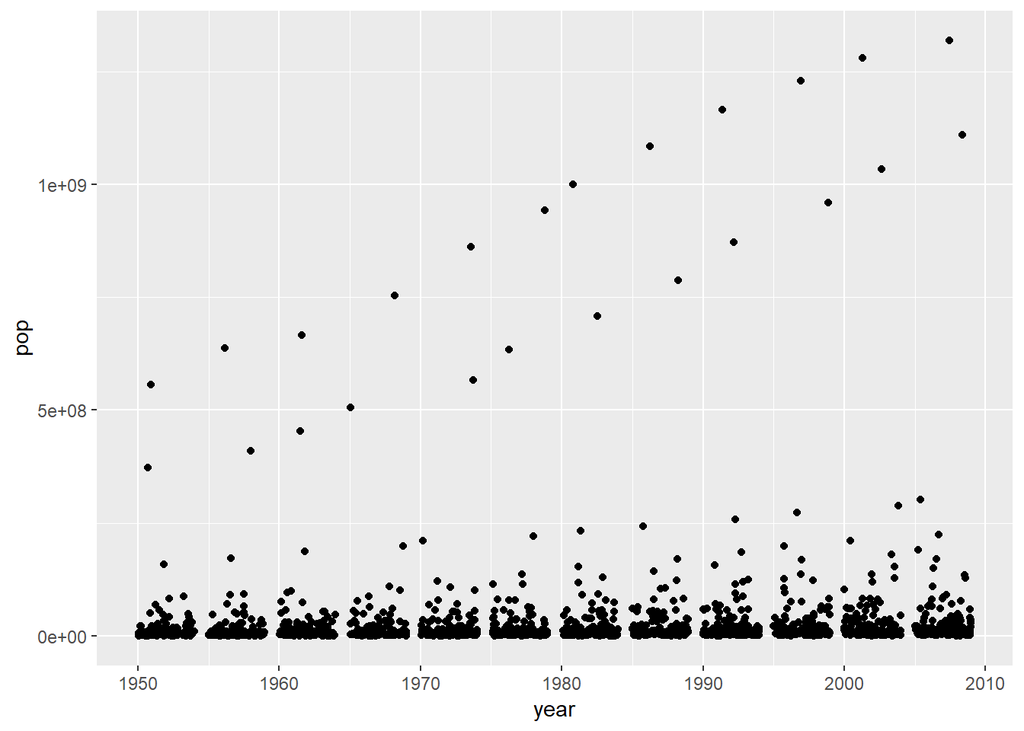

```r
# Changing alpha to 0.3 will make the dots more transparent. Some of the dots appear darker because there is actually more than one data point in the same place


ggplot(data = gapminder, aes(x = year, y = pop)) +
  geom_jitter()
```

```r
# Using geom_jitter instead of geom_point moves the points
```

**Exercise**: Change size and transparency using geom_jitter, so that the dots can be seen better.

### Colours, sizes, scales

In ggplot2, we can change things like the colour, size or shape of our data points, either by changing all of them, or by making them look different depending on another variable. We can change the colour of all dots by defining the colour within `geom_point()`:

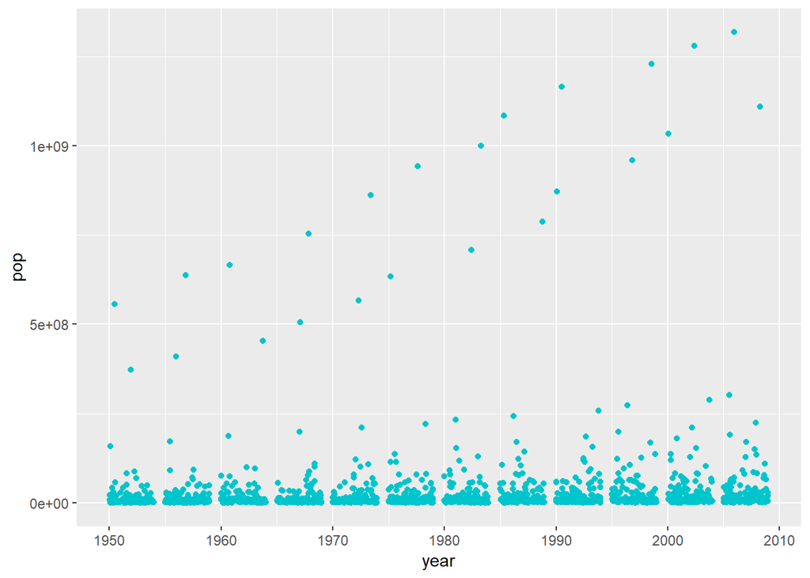

```r
ggplot(data = gapminder, aes(x = year, y = pop)) +
  geom_jitter(color = "turquoise3")
```

We could also change the colour of each dot, depending on the continent. To do so we need to add `aes` within `geom_point()`:

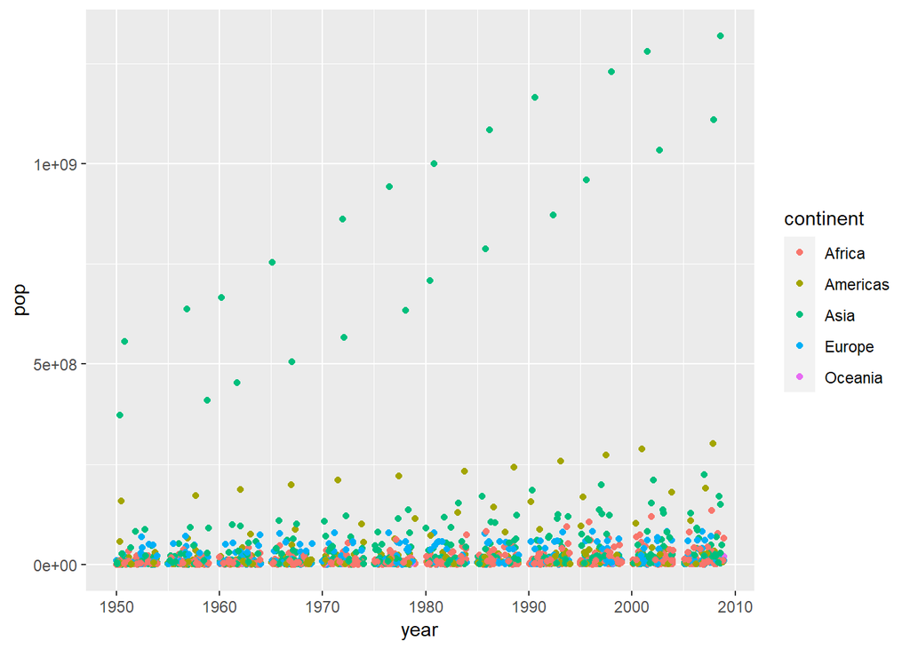

```r
ggplot(data = gapminder, aes(x = year, y = pop)) +
  geom_jitter(aes(color = continent))
```

```r
# Note that there is a legend in your plot now!
```

The plot will be made with default colours, different for each continent. To customise the colours, we need to adjust the scales:

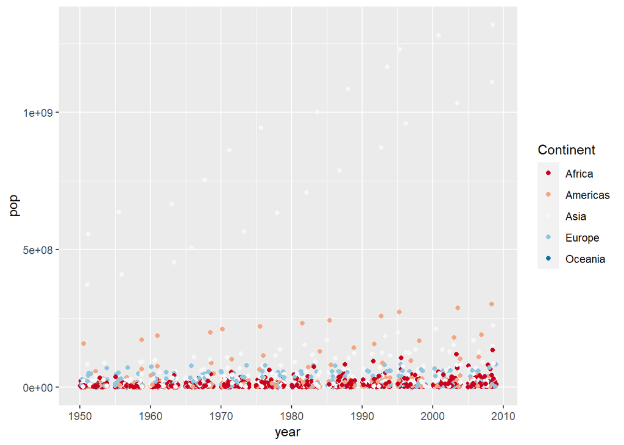

```r
ggplot(data = gapminder, aes(x = year, y = pop)) +
  geom_jitter(aes(colour = continent)) +
  scale_colour_brewer(palette = "RdBu", name = "Continent")
```

The scale function is used to customise how our data look, in this case we want to customise the colours in the plot. Whatever we specified in `geom_jitter` as an aesthetic, in this case colour, we need to put into the scale function: `scale_colour`. Here we will use colours from the RColorBrewer package, so we add `brewer` at the end. Inside the bracket we specify which colours we want to use, and `name` specifies the title of the legend. If you want to see all of the colour options in RColorBrewer, run the following code:

```r
library(RColorBrewer)

display.brewer.all()
```

**Exercise**: Change the colours of the plot, by picking a colour option from RColorBrewer.

In the previous example we used a categorical variable (continent) to set the colours. We can also use continuous variables for colours - the colours will change along a gradient:

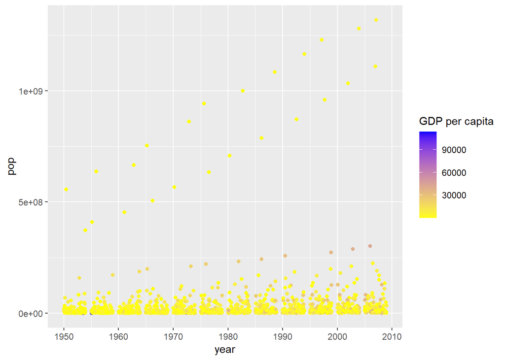

```r
ggplot(data = gapminder, aes(x = year, y = pop)) +
  geom_jitter(aes(colour = gdpPercap)) +
  scale_colour_gradient(low = "yellow", high = "blue", name = "GDP per capita")
```

In this example, we did not use RColorBrewer, but in-built R colour names. You can find a (very long) list of colour names in R here: http://www.stat.columbia.edu/~tzheng/files/Rcolor.pdf

**Exercise**: Change the colours in the plot, using the in-built R colour names.

**Exercise**: We can also change the size of the dot according to another variable. Instead of changing the colour, can you change the size of the dot according to the GDP variable? What is the difference in the code between making all dots bigger, and making them bigger depending on another variable?

### Shapes

We can change the dots to different symbols too, for example open circles or triangles. Each symbol corresponds to a number, which we add in `geom_point()` or `geom_jitter()`:

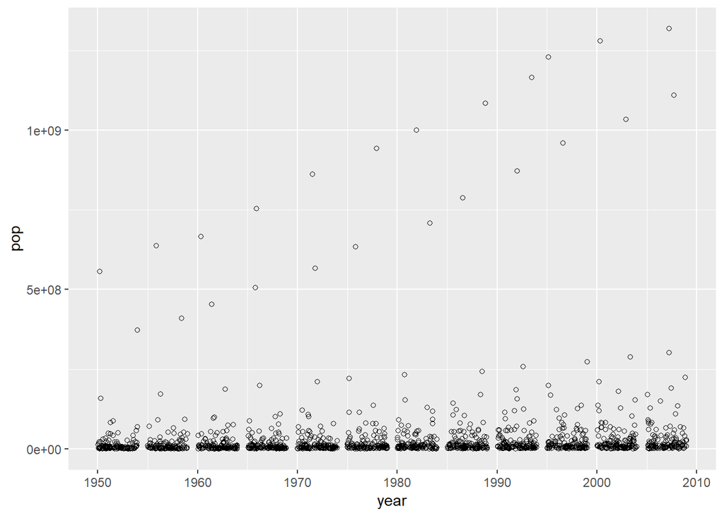

```r
ggplot(data = gapminder, aes(x = year, y = pop)) +
  geom_jitter(shape = 1)
```

**Exercise**: Can you change the symbol to a square, and then to a cross? Use the ggplot2 cheat sheet (link at the start of this document) to find which number corresponds to which.

## Customising the overall look of the plot

We can change the overall look of the plot by changing the theme. The theme will not affect how your plotted data look, just the setup of the plot:

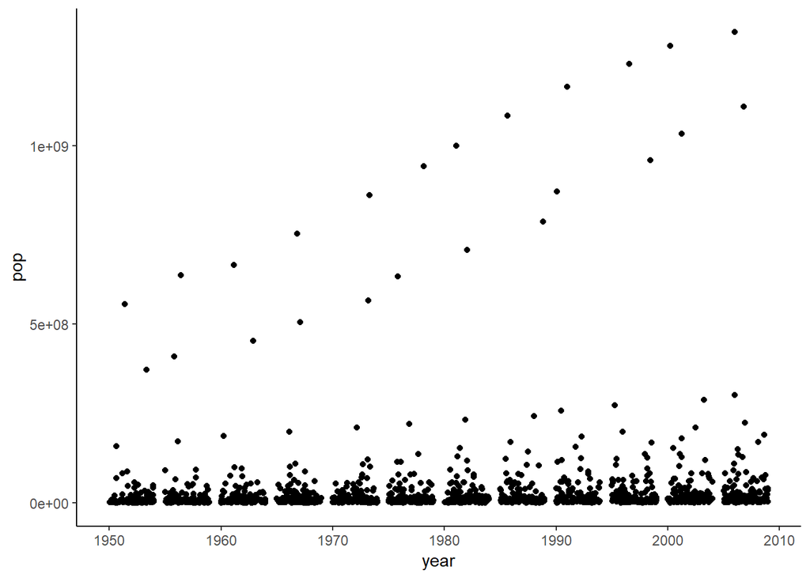

```r
ggplot(data = gapminder, aes(x = year, y = pop)) +
  geom_jitter() +
  theme_classic()
```

For a list of themes see http://ggplot2.tidyverse.org/reference/ggtheme.html.

**Exercise**: Try out three of the themes and see how the plots change.

## Using ggplot2 for different types of plots

Your plots will look different depending on the variables you are displaying - whether there are one, two or more to display, and whether they are categorical, ordinal or continuous.

### One continuous variable

If you have one continuous variable, you will likely use a histogram:

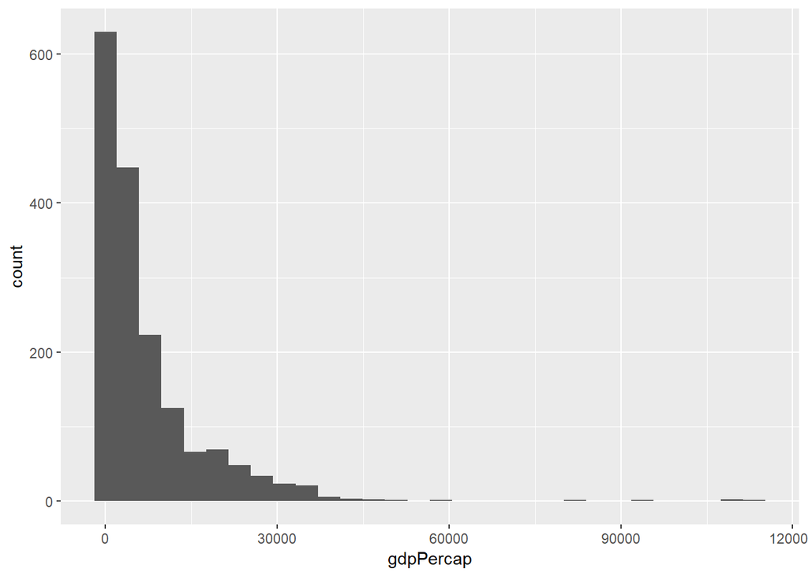

```r
ggplot(data = gapminder, aes(x = gdpPercap)) +
  geom_histogram()
```

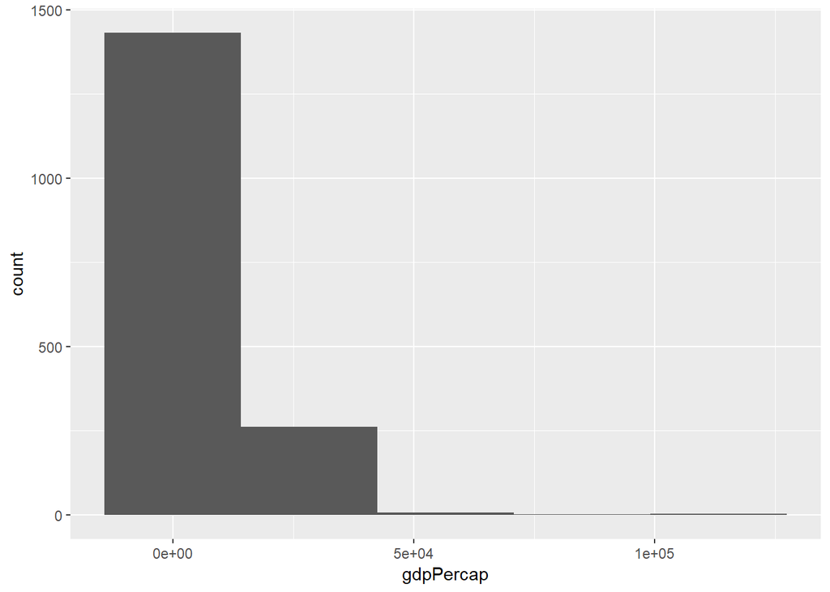

```r
ggplot(data = gapminder, aes(x = gdpPercap)) +
  geom_histogram(bins = 5)
```

**Exercise**: Change the number of bins until they show the pattern in the data clearly.

You could also use a density plot to display one continuous variable. Note what happens to the y-axis:

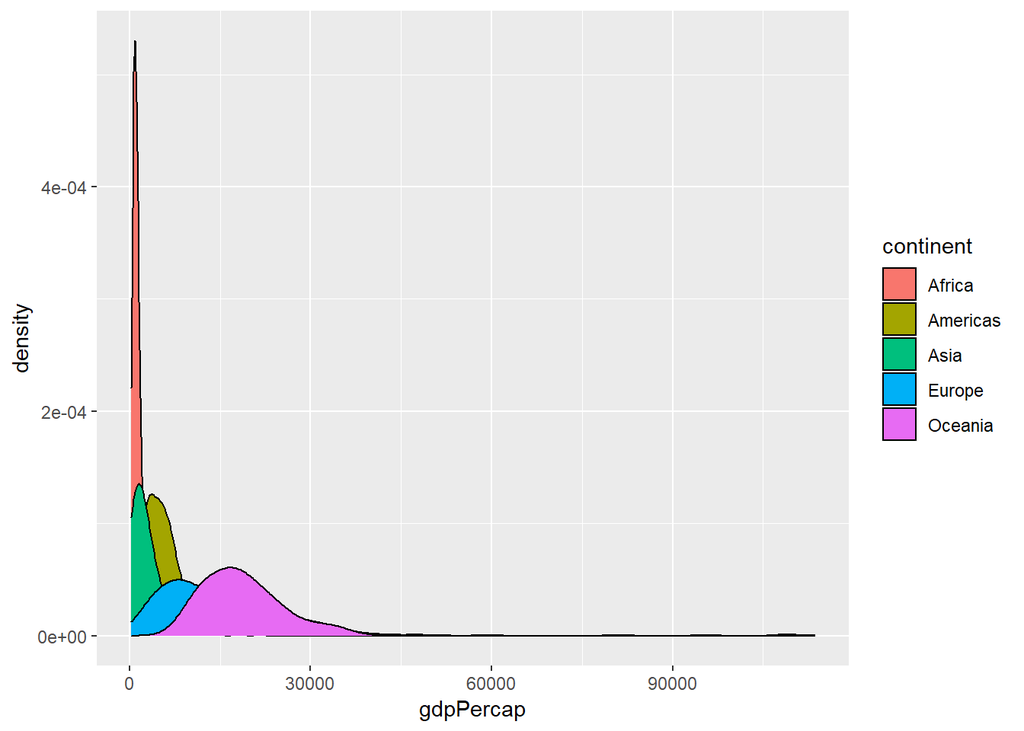

```r
ggplot(data = gapminder, aes(x = gdpPercap)) +
  geom_density(aes(fill = continent))
```

The area under the curve in a density plot sums to one, so the y-axis does not show a count, but a value between 0 and 1.

**Exercise**: In our last plot, the different densities were overlapping. Can you change the plot so we can see all densities at once?

### One categorical variable

If you have one categorical variable, you will need a bar graph. This will show a count of each of the categories:

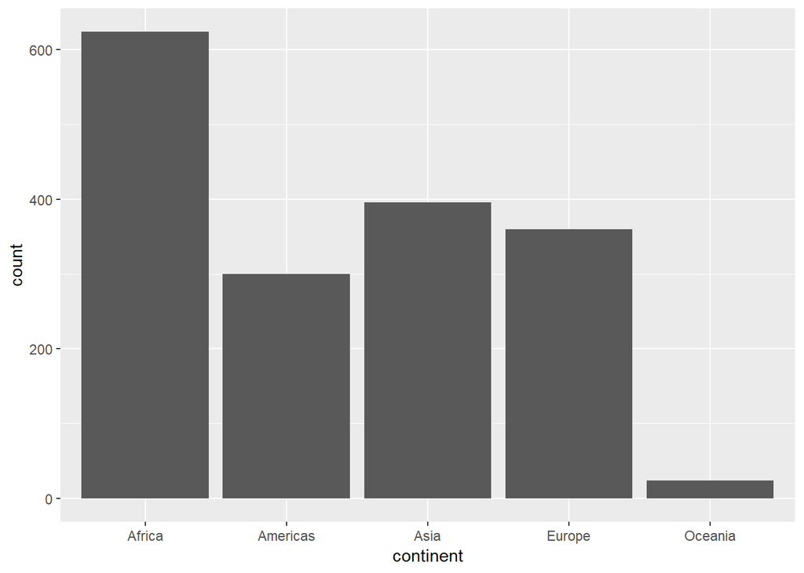

```r
ggplot(data = gapminder, aes(x = continent)) +
  geom_bar()
```

### Two continuous variables

If you have two continuous variables, you normally represent them with dots - see the examples we used at the start.

### One continuous and one categorical variable

If you have a categorical and a continuous variable, you would normally put the categorical variable on your x-axis and the continuous variable on your y-axis. These are often displayed as box plots (they show the four quartiles in the data, and outliers as dots):

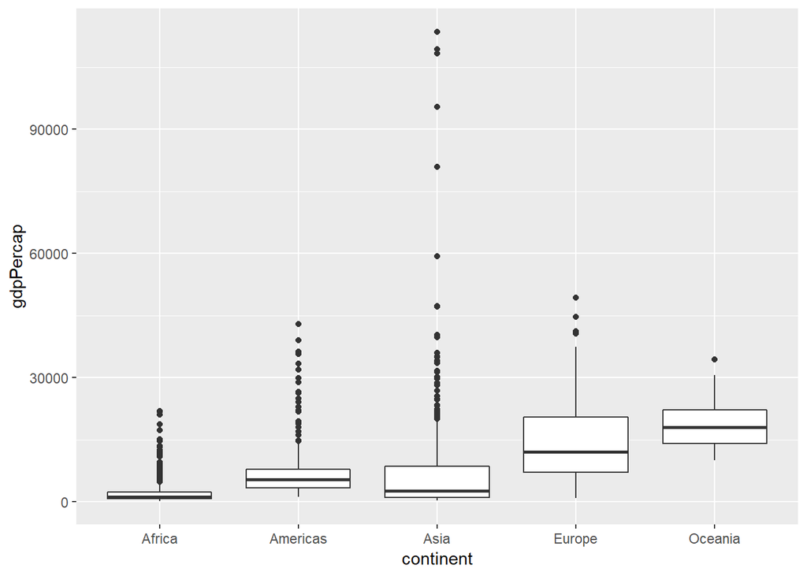

```r
ggplot(data = gapminder, aes(x = continent, y = gdpPercap)) +
  geom_boxplot()
```

Or you could present your data as a bar plot. The default `geom_bar()` option just uses a categorical variable for x. To show a categorical x and a continuous y variable, we need to add `stat="identity"` here:

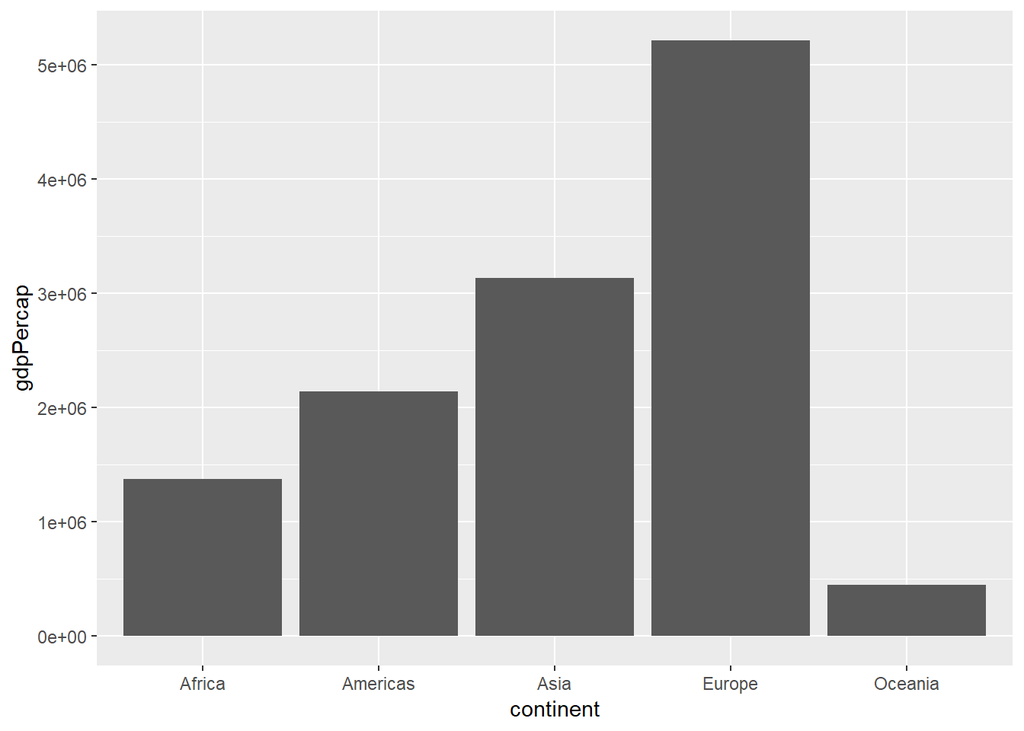

```r
ggplot(data = gapminder, aes(x = continent, y = gdpPercap)) +
  geom_bar(stat = "identity")
```

## Building an animated plot

We will start building a plot with geom_point:

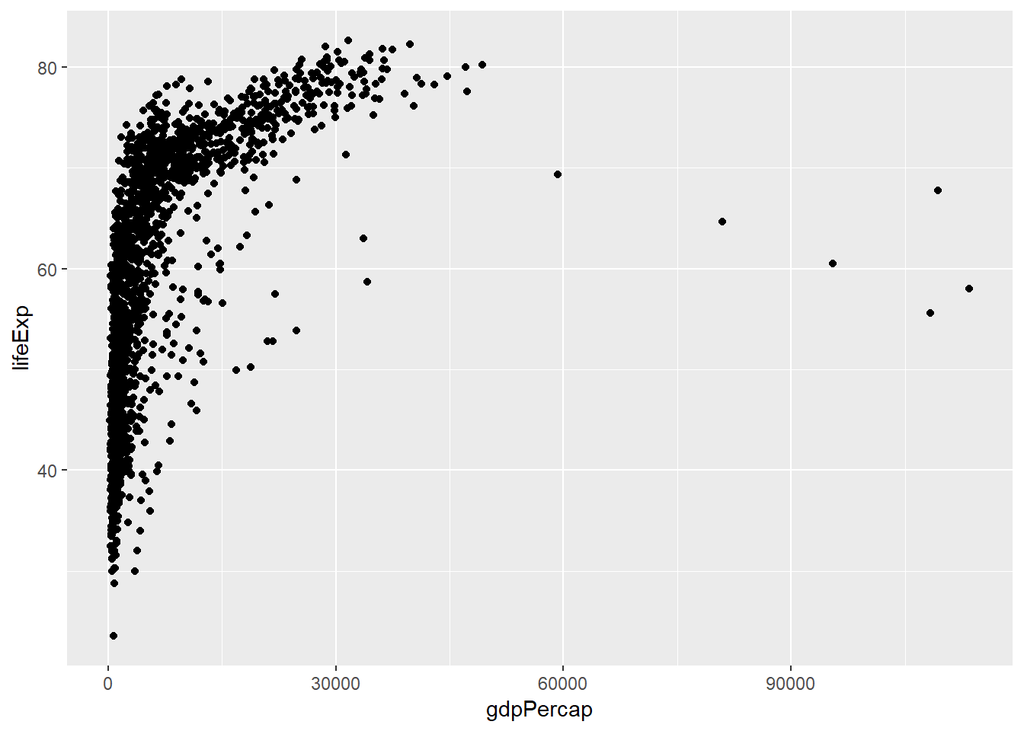

```r
ggplot(data = gapminder, aes(x = gdpPercap, y = lifeExp)) +
  geom_point()
```

**Exercise**: Change the size of the points according to the variable pop, and the colour according to the continent.

Now we will make the points a bit more transparent, by setting alpha. We will also change the colour of the points:

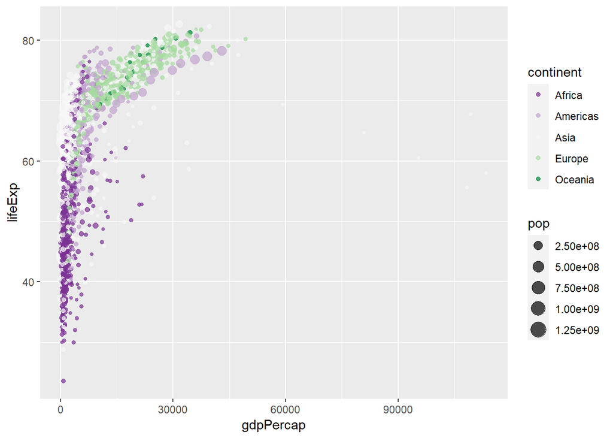

```r
ggplot(data = gapminder, aes(x = gdpPercap, y = lifeExp,  size = pop, colour = continent)) +
  geom_point(alpha = .7) +
  scale_colour_brewer(palette = "PRGn")
```

**Exercise**: Change the palette to a different one. Check http://colorbrewer2.org/ for more palettes, and pick one that is colour-blind friendly.

Now we will make subplots, by splitting the data according to the continent:

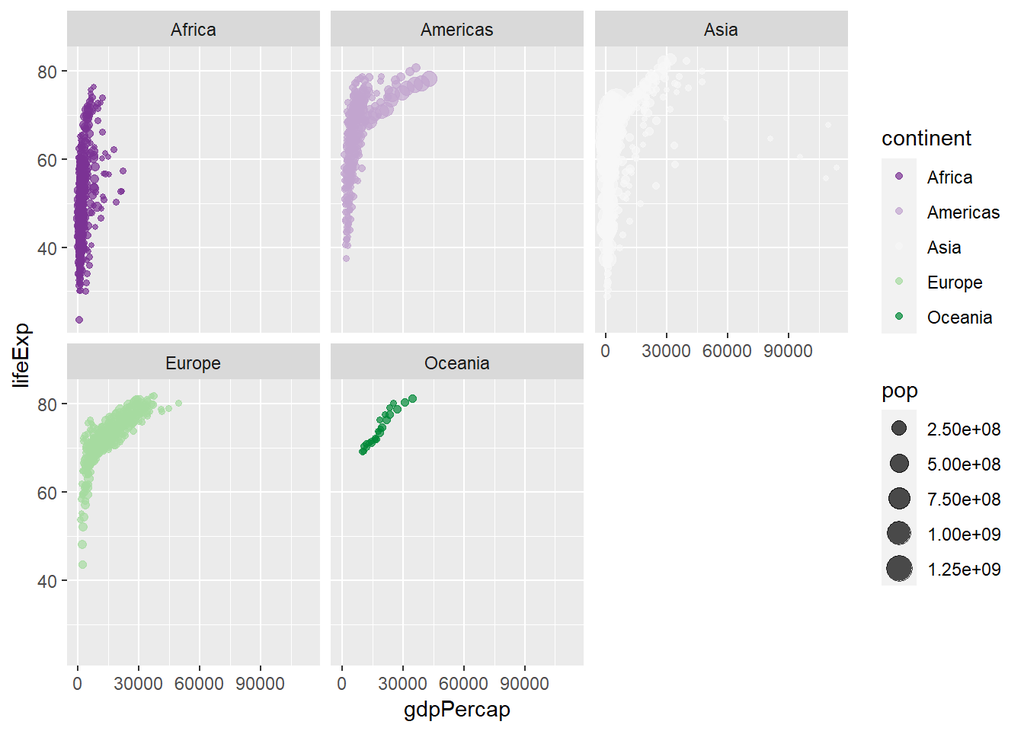

```r
ggplot(data = gapminder, aes(x = gdpPercap, y = lifeExp,  size = pop, colour = continent)) +
  geom_point(alpha = .7) +
  facet_wrap(~ continent) +  # we need ~ in front of the variable, as we could facet by another     # variable - then the format would be facet_wrap(variable1 ~ variable2)
  scale_colour_brewer(palette = "PRGn")
```

We will change a few more things, to make sure this will look really nice in the end:

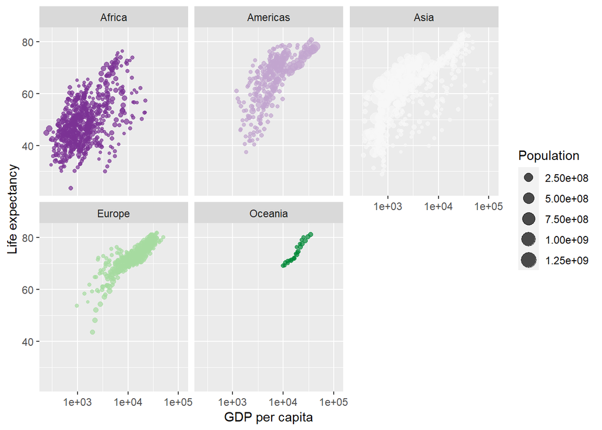

```r
ggplot(data = gapminder, aes(x = gdpPercap, y = lifeExp,  size = pop, colour = continent)) +
  geom_point(alpha = .7) +
  facet_wrap(~ continent) +
  scale_colour_brewer(palette = "PRGn") +
  scale_size(name = "Population") +
  guides(colour = "none") +
  scale_x_log10() +
  labs(x = 'GDP per capita', y = 'Life expectancy')
```

**Exercise**: What happens in each of the last 4 lines of code?

Finally, we will add the code to make the plot show each year individually. We use the function `transition_time` from the `gganimate` package:

```r
ggplot(data = gapminder, aes(x = gdpPercap, y = lifeExp,  size = pop, colour = continent)) +
  geom_point(alpha = .7) +
  facet_wrap(~ continent) +
  scale_colour_brewer(palette = "PRGn") +
  scale_size(name = "Population") +
  guides(colour = "none") +
  scale_x_log10() +
  labs(title = 'Year: {frame_time}', x = 'GDP per capita', y = 'Life expectancy') +
  transition_time(year)
```

## Saving a plot

Your plots will be saved in the folder that you set as your working directory. This line of code will save the last ggplot you made to a pdf:

```r
ggplot(data = gapminder, aes(x = gdpPercap, y = lifeExp)) +
  geom_point()
ggsave("plot.pdf")
```

Or you can save it as a jpg:

```r
ggsave("plot.jpg")
```

You can specify the size by adding dpi. You can also specify the exact width and height (in inches) which is useful for publications:

```r
ggsave("plot.pdf", dpi=300, width=5, height=5)
```